# Solution 6

**Problem 2**

We learned of three measures for impurity used by classification trees. Plot the expressions for misclassification error, Gini index, and cross-entropy as functions of $p$. When you plot cross-entropy, you can scale it by a constant so that it is equal to 1/2 when $p$ = 1/2. Are the curves similar?

**Ans:** The three impurity measures are plotted, with cross-entropy scaled by a factor of 1/2 to bring it to the same range as the Gini index. We see the Gini Index and the Cross-entropy are similar, they both maximize at p = 1/2 and both are concave. The misclassification rate is obviously different in the sense that it is linear, however it shares many of the same properties: it is maximized at p = 1/2, equals zero at p = 0,1 and it is concave.

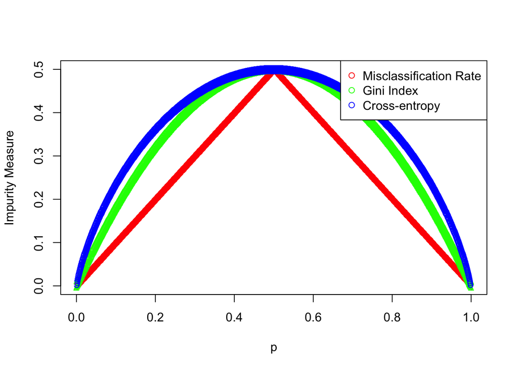

```r
p <- seq(0, 1, 0.001)

# misclassification rate
miscl <- 1 - pmax(p, 1-p)

# Gini index
gini <- 2*p*(1-p)

# Cross entropy
ce <- (p * log((1-p)/p) - log(1-p)) / (2*log(2))

matplot(p, cbind(miscl, gini, ce), col=c("red", "green", "blue"), ylab = "Impurity Measure")
legend("topright",pch=21,col=c("red", "green", "blue"), legend=c("Misclassification Rate","Gini Index","Cross-entropy"))
```

**Problem 4**

This problem involves the “OJ” data set which is part of the “ISLR” package.

**Q4a.** Create a training set containing a random sample of 800 observations, and a test set containing the remaining observations.

**Q4b.** Fit a tree to the training data, with “Purchase” as the response and the other variables except for “Buy” as predictors. Use the “summary()” function to produce summary statistics about the tree, and describe the results obtained. What is the training error rate ? How many terminal nodes does the tree have?

**Q4c.** Type in the name of the tree object in order to get a detailed text output. Pick one of the terminal nodes, and interpret the information displayed.

```r
library(tree)
library(ISLR)
set.seed(3)
tr <- sample(1:nrow(OJ), 800)
oj.tr <- OJ[tr,]
oj.te <- OJ[-tr,]
tree.oj <- tree(Purchase ~., oj.tr)
summary(tree.oj)
```

```
##
## Classification tree:
## tree(formula = Purchase ~ ., data = oj.tr)
## Variables actually used in tree construction:
## [1] "LoyalCH"       "PriceDiff"     "ListPriceDiff"
## Number of terminal nodes:  7
## Residual mean deviance:  0.7425 = 588.8 / 793
## Misclassification error rate: 0.1575 = 126 / 800
```

```r
tree.oj
```

```
## node), split, n, deviance, yval, (yprob)
##       * denotes terminal node
##
##  1) root 800 1064.00 CH ( 0.61750 0.38250 )
##    2) LoyalCH < 0.48285 290  308.60 MM ( 0.22414 0.77586 )
##      4) LoyalCH < 0.051325 55    0.00 MM ( 0.00000 1.00000 ) *
##      5) LoyalCH > 0.051325 235  277.20 MM ( 0.27660 0.72340 )
##       10) PriceDiff < 0.31 186  193.70 MM ( 0.21505 0.78495 ) *
##       11) PriceDiff > 0.31 49   67.91 CH ( 0.51020 0.48980 ) *
##    3) LoyalCH > 0.48285 510  446.50 CH ( 0.84118 0.15882 )
##      6) LoyalCH < 0.764572 244  294.30 CH ( 0.70902 0.29098 )
##       12) PriceDiff < 0.145 96  133.00 MM ( 0.48958 0.51042 )
##         24) ListPriceDiff < 0.235 65   84.47 MM ( 0.35385 0.64615 ) *
##         25) ListPriceDiff > 0.235 31   33.12 CH ( 0.77419 0.22581 ) *
##       13) PriceDiff > 0.145 148  124.40 CH ( 0.85135 0.14865 ) *
##      7) LoyalCH > 0.764572 266   85.24 CH ( 0.96241 0.03759 ) *
```

**Q4d.** Create a plot of the tree, and interpret the results.

**Q4e.** Predict the response on the test data, and produce a confusion matrix comparing the test labels to the predicted test labels. What is the test error rate?

We plot the tree with the following command.

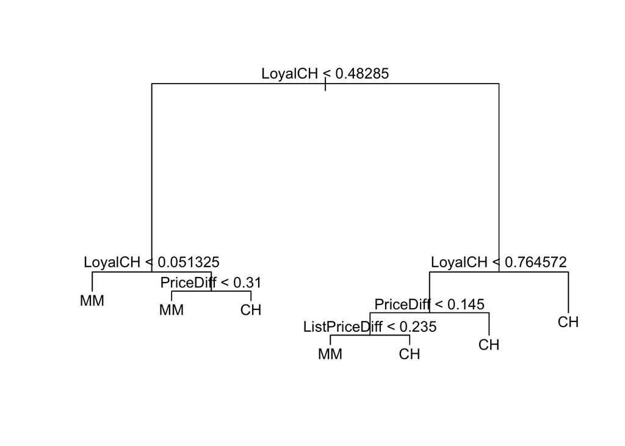

```r
plot(tree.oj, main='OJ Purchase Decision Tree')
text(tree.oj, pretty=0)
```

We apply this tree to our test set, and observe it obtains about 20% test error.

```r
full.te.predict <- predict(tree.oj, oj.te, type='class')
table(full.te.predict, oj.te$Purchase)
```

```
##
## full.te.predict  CH  MM
##              CH 132  27
##              MM  27  84
```

```r
mean(full.te.predict != oj.te$Purchase)
```

```
## [1] 0.2
```

**Q4f.** Apply the “cv.tree()” function to the training set in order to determine the optimal size tree.

**Q4g.** Produce a plot with tree size on the x-axis and cross-validated classification error rate on the y-axis.

**Q4h.** Which tree size corresponds to the lowest cross-validated classification error rate?

**Q4i.** Produce a pruned tree corresponding to the optimal tree size obtained using cross-validation. If cross-validation does not lead to selection of a pruned tree, then create a pruned tree with five terminal nodes.

**Q4j.** Compare the training error rates between the pruned and unpruned trees. Which is higher?

**Q4k.** Compare the test error rates between the pruned and unpruned trees. Which is higher?

**Ans 4f-k:** We compute the cross validation error whilst pruning the tree, and it vs tree size. We see it is minimized when the size is equal to 2 or 7. We choose the simpler model. We create the pruned tree and compare training/testing errors.

```r
# Apply cv.tree() to the training set to determine the optimal size tree
cv.oj <- cv.tree(tree.oj, FUN = prune.misclass)
cv.oj
```

```
## $size
## [1] 7 5 2 1
##
## $dev
## [1] 151 153 151 306
##
## $k
## [1]       -Inf   0.500000   6.333333 160.000000
##
## $method
## [1] "misclass"
##
## attr(,"class")
## [1] "prune"         "tree.sequence"
```

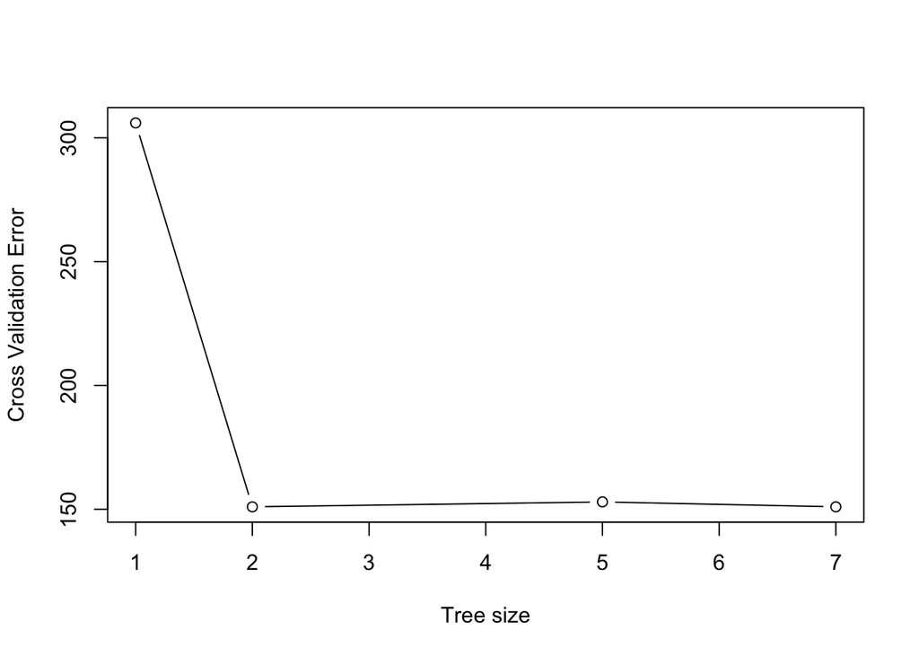

```r
plot(cv.oj$size, cv.oj$dev, type = "b", xlab = "Tree size", ylab = "Cross Validation Error")
```

We choose the simpler model of size 2.

```r
prune.oj <- prune.misclass(tree.oj, best = 2)
mean(predict(prune.oj, oj.tr, type='class')!=oj.tr$Purchase)
```

```
## [1] 0.1825
```

```r
mean(predict(prune.oj, oj.te, type='class')!=oj.te$Purchase)
```

```
## [1] 0.2148148
```

Unpruned: Train = 15.8%, Test = 20%. Pruned: Train = 18.3%, Test = 21.5%. In this case we sacrifice some bias for a significantly lower variance model, it does appear to be slightly over-pruned however.

**Problem 5**

We now use boosting to predict “Salary” in the “Hitters” data set.

**Q5a.** Remove the observations for whom the salary information is unknown, and then log-transform the salaries.

**Q5b.** Create a training set consisting of the first 200 observations, and a test set consisting of the remaining observations.

**Q5c.** Perform boosting on the training set with 1000 trees for a range of values of the shrinkage parameter λ. Produce a plot with different shrinkage values on the x-axis and the corresponding training set MSE on the y-axis.

**Q5d.** Produce a plot with different shrinkage values on the x-axis and the corresponding test set MSE on the y-axis.

```r
library(ISLR)
full.hit <- Hitters[!is.na(Hitters$Salary),]
full.hit$Salary <- log(full.hit$Salary)

tr <- sample(1:nrow(full.hit), 200)
hit.tr <- full.hit[tr,]
hit.te <- full.hit[-tr,]

shrinkage <- seq(0,0.03,0.00005)
tr.mse <- array(NA,length(shrinkage))
te.mse <- array(NA,length(shrinkage))

library(gbm)
for (i in 1:length(shrinkage)) {
  hit.boost <- gbm(Salary ~., data=hit.tr, distribution='gaussian',
        n.trees=1000, shrinkage=shrinkage[i], verbose=F)
    tr.mse[i] <- mean((predict(hit.boost, hit.tr, n.trees=1000) - hit.tr$Salary)^2)
    te.mse[i] <- mean((predict(hit.boost, hit.te, n.trees=1000) - hit.te$Salary)^2)
}
```

**Q5e.** Compare the test MSE of boosting to the test MSE that results from applying two of the regression approaches.

**Ans:** We compare the boosting’s minimum test error of 0.456 with the test error with that of a simple linear model, and also lasso regression. Linear regression obtains a slightly better MSE than lasso, which is unsurprising as we have a much larger number of samples than covariates so we don’t really need to enforce sparsity. Nevertheless the MSE of linear regression, 0.62, is vastly greater than boosting’s 0.45. Boosting wins.

```r
min(te.mse)
```

```
## [1] 0.4562451
```

```r
#Linear Regression
hit.lm <- lm(Salary ~., hit.tr)
mean((predict(hit.lm, hit.te) - hit.te$Salary)^2)
```

```
## [1] 0.6197796
```

```r
library(glmnet)
hit.las.cv <- cv.glmnet(as.matrix(hit.tr[,-c(19,20,14,15)]),
  as.matrix(hit.tr[,19]), alpha=1)
hit.las <- glmnet(as.matrix(hit.tr[,-c(19,20,14,15)]),
    as.matrix(hit.tr[,19]), alpha=1, lambda=hit.las.cv$lambda.min)
mean((predict(hit.las,
    as.matrix(hit.te[,-c(19,20,14,15)])) - hit.te$Salary)^2)
```

```
## [1] 0.6234914
```

**Q5f.** Which variables appear to be the most important predictors in the boosted model?

**Q5g.** Now apply bagging to the training set. What is the test set MSE for this approach?

**Ans 5f,g:** We investigate the variable importance by plotting our boosting model, using the `summary()` command.

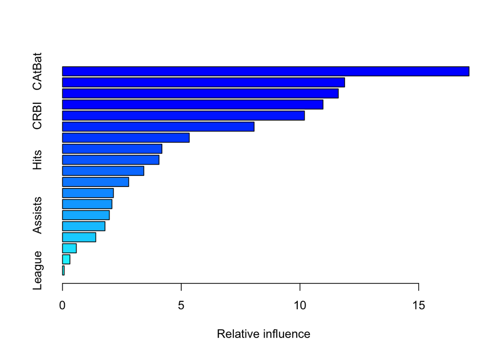

```
##                 var     rel.inf
## CAtBat       CAtBat 17.12225220
## CHits         CHits 11.88204260
## CWalks       CWalks 11.61496809
## Years         Years 10.97025215
## CRBI           CRBI 10.18958637
## CRuns         CRuns  8.06930839
## Walks         Walks  5.33778650
## RBI             RBI  4.18705159
## Hits           Hits  4.06495255
## CHmRun       CHmRun  3.42448764
## PutOuts     PutOuts  2.78745666
## Runs           Runs  2.14431093
## AtBat         AtBat  2.08156042
## Assists     Assists  1.97223968
## Errors       Errors  1.78803399
## HmRun         HmRun  1.40023607
## NewLeague NewLeague  0.58188296
## Division   Division  0.31233474
## League       League  0.06925648
```

```r
summary(hit.boost)
```

We apply bagging to the training set, using random forests specifically. To enforce bagging, and not variable subsampling, we assign mtry to equal the number of covariates in our model, which is 19. The observed test MSE 0f 0.48 is considerably better than that of linear or lasso regression, however it is still slightly greater than boosting’s 0.45.

```r
library(randomForest)
hit.rf <- randomForest(Salary ~., hit.tr, mtry=(ncol(hit.tr)-1), importance=T)
mean((predict(hit.rf, hit.te) - hit.te$Salary)^2)
```

```
## [1] 0.4896535
```